# Predicting the Inflation Rate with CPI and PPI Using Machine Learning Methods

Group Members:

- Wang Qiman (1155183652)
- Li Wanqi (1155184632)
- Tang Hui (1155180566)

## CONTENTS

1. Variable Selection
2. Selection of Four Model
3. ARIMA——without any X-predictors as a Benchmark Model
4. Dynamic Factor Model with Principal Component Analysis
5. ARIMA——with Principal Component Analysis
6. Random Forest
7. Model Comparison and Data Choose for Inflation Rate Forecast

## 1. Variable Selection

Among the 152 variables provided in the task, a significant number of them exhibit correlations with CPI (Consumer Price Index) or PPI (Producer Price Index). However, in order to prevent over-fitting of the model, it is crucial to control the quantity of predictor variables and proceed with a meticulous selection process. As a result, we have opted to exclusively choose variables that display a strong correlation with CPI and PPI as predictors for the machine learning model.

Our initial step involves conducting a thorough review of academic papers pertaining to the factors influencing CPI and PPI, both within China and in other countries such as the US and Russia. From these past empirical research studies, we extract a selection of 24 variables that serve as predictors for CPI, as well as 15 variables that predict PPI. These variables are chosen specifically for their strong correlations with CPI and PPI. Given that our primary objective is to forecast the inflation rate in China, we prioritize literature that primarily focuses on domestic sources.

Additionally, we consider variables that, from an economic standpoint, are intuitively expected to have a significant impact on or exhibit a strong correlation with CPI and PPI. They might be correlated with CPI and PPI through price, money supply, market expectations, and so on.

The specific predictors of each category are saved as “Final Predictors.xlsx” in our repository.

## 2. Selection of Four Model

### 2.1 ARIMA——without any X-predictors as a Benchmark Model

In this model, we utilize only lagged predicted variables from the model itself to forecast the next 30 monthly CPI and PPI values.

ARIMA, which stands for Auto Regressive Integrated Moving Average, is a widely used time series model that takes into account both autocorrelation and trend to predict future values. Its popularity stems from its simplicity and effectiveness in modeling and forecasting time series data. Given that our project revolves around predicting time series data for CPI and PPI, the ARIMA model is a suitable choice as it aligns well with the nature of our task.

In the subsequent three models, we will employ our selected predictors.

### 2.2 Dynamic Factor Models with Principal Component Analysis

Dynamic Factor Models with Principal Component Analysis (DFMs with PCA) are an innovative approach within the realm of statistical models. The technique is aimed at capturing the shared latent factors that influence a large set of variables over time. By integrating PCA into DFMs, the intention is to enhance the management of high-dimensional time series data by reducing dimensionality and extracting significant features, thus improving interpretability.

In our project, we tested DFMs with PCA with the hope of capturing the common underlying factors influencing our variables and enhancing our forecasting tasks, particularly for predicting CPI and PPI.

### 2.3 ARIMA——with Principal Component Analysis

During the course of our project, the application of DFMs with PCA encountered challenges and we introduced an alternative approach: ARIMA+PCA. ARIMA with PCA represents a sophisticated approach in the field of time series forecasting. ARIMA models are known for their ability to capture various temporal structures, while PCA is a dimension-reduction technique that isolates significant features in high-dimensional dataset. The integration of PCA into ARIMA aims to enhance the model’s performance by reducing dimensionality and improving interpretability.

In the subsequent sections of this paper, we will explore the utilization of ARIMA integrated with PCA, detailing the theoretical underpinnings, model implementation, and the expected advantages of this combined approach.

### 2.4 Random Forest

Random Forest is a highly popular ensemble learning algorithm that leverages multiple decision trees to enhance predictive performance and alleviate overfit. It demonstrates robust capabilities for both classification and regression tasks, making it particularly well-suited for forecasting CPI and PPI, among other dataset.

Considering these factors, Random Forest emerges as a sensible and effective choice for predicting CPI and PPI within our project.

## 3. ARIMA——without any X-predictors as a Benchmark Model

In this model, as mentioned before, we only introduce two data sets, cpi and ppi, and use ARIMA specifically for time series analysis.

First, we transform the CPI/PPI into time-series data. Then, we use the “auto.arima” command to automatically select an appropriate ARIMA model.

```r
rm(list = ls())
load(url("https://github.com/zhentaoshi/Econ5821/raw/main/data_example/dataset_inf.Rdata"))
#install.packages("forecast")   # Install the forecast package
library(forecast)              # Load the forecast package
cpi_ts <- ts(cpi[, 2])
arima_model <- auto.arima(cpi_ts)
predictions <- forecast(arima_model, h = 30)
print(predictions)
```

```
##     Point Forecast    Lo 80    Hi 80     Lo 95    Hi 95
## 169       102.2766 101.5423 103.0109 101.15362 103.3996
## 170       102.4244 101.4355 103.4133 100.91206 103.9368
## 171       102.5715 101.3681 103.7750 100.73098 104.4121
## 172       102.7145 101.3263 104.1026 100.59142 104.8375
## 173       102.8501 101.3038 104.3963 100.48523 105.2149
## 174       102.9755 101.2963 104.6547 100.40737 105.5437
## 175       103.0884 101.3003 104.8765 100.35374 105.8231
## 176       103.1868 101.3125 105.0610 100.32034 106.0532
## 177       103.2690 101.3296 105.2084 100.30294 106.2351
## 178       103.3341 101.3482 105.3199 100.29701 106.3712
## 179       103.3814 101.3651 105.3977 100.29774 106.4651
## 180       103.4108 101.3768 105.4447 100.30014 106.5214
## 181       103.4225 101.3803 105.4647 100.29923 106.5458
## 182       103.4173 101.3726 105.4619 100.29025 106.5443
```

[output cut: 16 more lines]

We then plot the predicted values of the cpi, along with the predicted values within the 95% confidence interval.

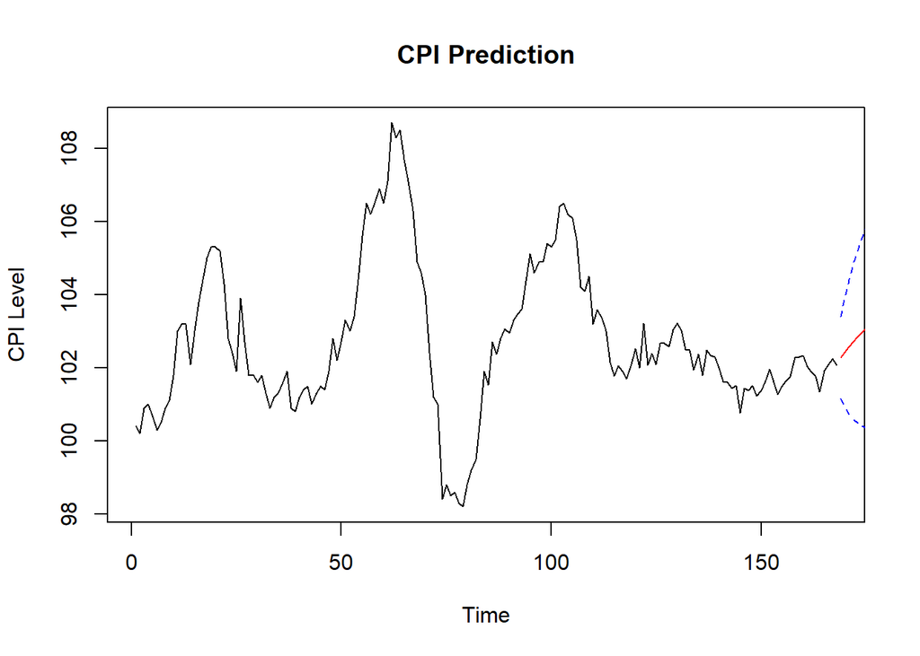

```r
# Plotting the historical CPI data
plot(cpi_ts, main = "CPI Prediction", ylab = "CPI Level")
# Add the predicted values to the plot
lines(predictions$mean, col = "red")  # Mean predictions
lines(predictions$lower[, "95%"], col = "blue", lty = "dashed")  # 95% confidence interval lower bound
lines(predictions$upper[, "95%"], col = "blue", lty = "dashed")  # 95% confidence interval upper bound
```

In the same way, we forecast the ppi value and plot it along with the 95% confidence interval.

```r
ppi_ts <- ts(ppi[, 2])
arima_model <- auto.arima(ppi_ts)
predictions <- forecast(arima_model, h = 30)
print(predictions)
```

```
##     Point Forecast     Lo 80    Hi 80     Lo 95    Hi 95
## 169       107.0915 106.33325 107.8498 105.93184 108.2512
## 170       108.0741 106.36138 109.7868 105.45473 110.6934
## 171       108.6452 105.95587 111.3346 104.53221 112.7583
## 172       108.9730 105.37093 112.5750 103.46412 114.4818
## 173       109.1619 104.73036 113.5935 102.38444 115.9394
## 174       109.2716 104.08888 114.4543 101.34532 117.1979
## 175       109.3355 103.46914 115.2019 100.36366 118.3074
## 176       109.3728 102.87939 115.8663  99.44196 119.3037
## 177       109.3946 102.32135 116.4679  98.57699 120.2123
## 178       109.4073 101.79383 117.0208  97.76349 121.0512
## 179       109.4147 101.29443 117.5351  96.99580 121.8337
## 180       109.4191 100.82042 118.0177  96.26856 122.5696
## 181       109.4216 100.36909 118.4741  95.57698 123.2662
## 182       109.4231  99.93799 118.9082  94.91689 123.9293
```

[output cut: 16 more lines]

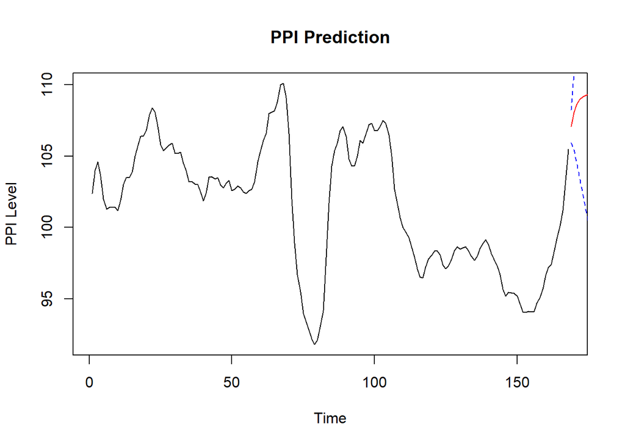

```r
# Plotting the historical PPI data
plot(ppi_ts, main = "PPI Prediction", ylab = "PPI Level")
# Add the predicted values to the plot
lines(predictions$mean, col = "red")  # Mean predictions
lines(predictions$lower[, "95%"], col = "blue", lty = "dashed")  # 95% confidence interval lower bound
lines(predictions$upper[, "95%"], col = "blue", lty = "dashed")  # 95% confidence interval upper bound
```

This is the preliminary exploration of our group. We use auto.arima to make simple prediction on the data of PPI and CPI from period 1 to 168 without introducing X and fake.X variables.

## 4. Dynamic Factor Model with Principal Component Analysis

Upon implementation, however, the DFM with PCA approach did not yield the expected performance for predicting CPI and PPI within our project. Despite the theoretical advantages, the results did not match our expectations. The PCA component, while designed to provide robustness by isolating significant variables, did not enhance the precision and interpretability of our forecasts as much as we had hoped.

```r
rm(list = ls())
load(url("https://github.com/zhentaoshi/Econ5821/raw/main/data_example/dataset_inf.Rdata"))
library(dfms)
library(forecast)
selected_cols <- c(14:18, 26, 28, 30, 34:35, 41, 48:51, 55, 57, 64, 66:70, 75:81, 94, 100:125, 127:129, 140:142, 147, 150)
cpi <- as.matrix(ts(cpi[,2], start = 1, frequency = 12)) # Assuming monthly data
X <- as.matrix(ts(X[,selected_cols], start = 1, frequency = 12))
fake.testing.X <- as.matrix(ts(fake.testing.X[,selected_cols], start = 169, frequency = 12))
```

Here we conduct principal component analysis, principal component factor selection, and predict the factors after selection. Our team will explain the specific methods and steps in the fifth part of arima+pca.

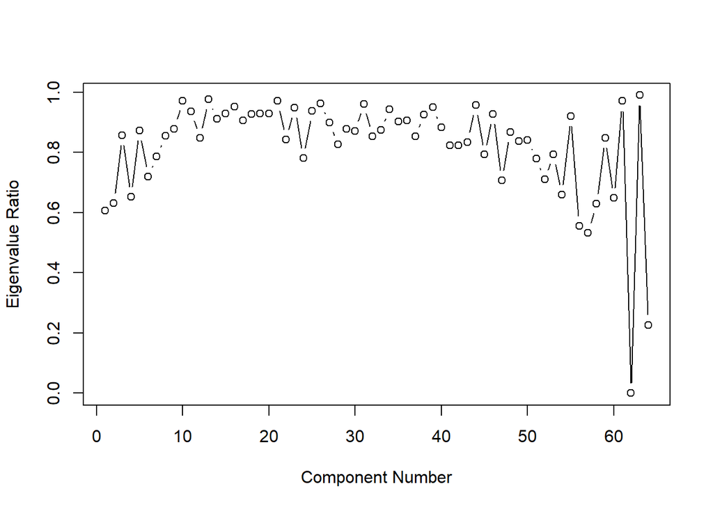

```r
pca <- prcomp(X, scale = TRUE)
PC <- pca$x
eig_ratio <- pca$sdev[-1]^2 / pca$sdev[-length(pca$sdev)]^2
plot(eig_ratio, type = "b", ylab = "Eigenvalue Ratio", xlab = "Component Number")
```

```r
n_factors <- sum(pca$sdev^2 > 1)
n_factors <- 19
factors <- pca$x[, 1:n_factors]
dfm_data <- data.frame(cbind(cpi, factors))
# Fit the DFM model
dfm_model <- DFM(dfm_data, r= 5, p = 3)
```

```
## Converged after 63 iterations.
```

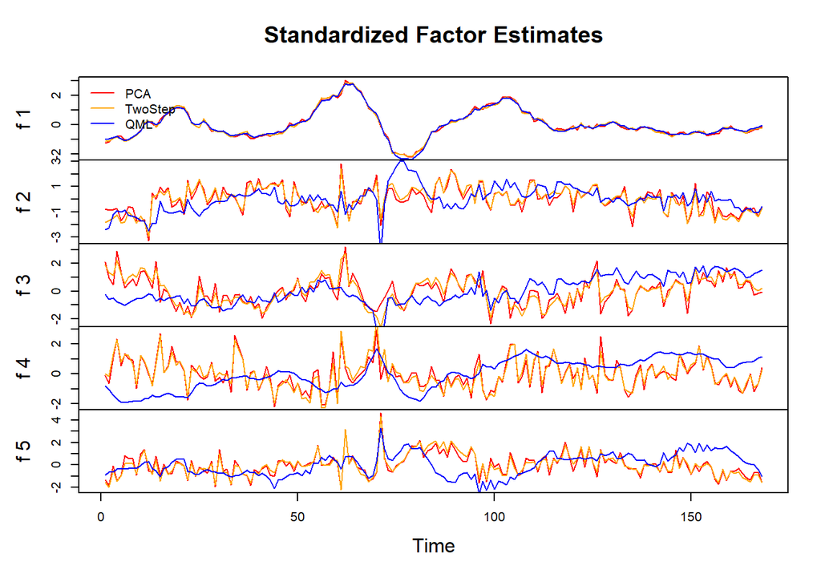

```r
plot(dfm_model, method = "all", type = "individual")
```

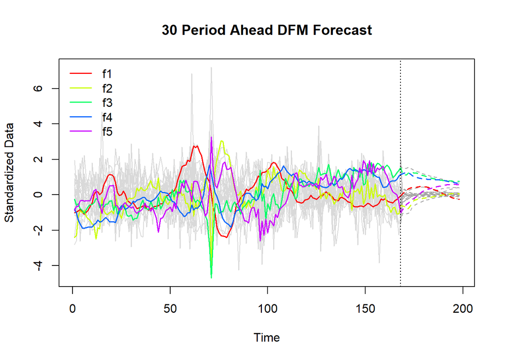

```r
forecast_values <- predict(dfm_model, newdata = fake.testing.X, h=30)
plot(forecast_values)
```

Due to technical reasons, the DFM() model selected by our team fails to effectively distinguish the dependent variable from the independent variable, and fails to combine the values of CPI1-168 periods and the macro data of testing. Therefore, the team considered that this method failed and carried out the following arima+pca modeling prediction.

## 5. ARIMA——with Principal Component Analysis

Encountering the challenges with DFM integrated with PCA prompted us to seek an alternative modeling strategy. We turned our attention towards the ARIMA with PCA model.

In this section, we will walk through our journey with the ARIMA integrated with PCA model, from its implementation to the outcomes. This transition to ARIMA with PCA highlights the adaptive nature of data science and the need for constant reassessment and adjustment in our modeling techniques to achieve optimal results.

```r
rm(list = ls())
load(url("https://github.com/zhentaoshi/Econ5821/raw/main/data_example/dataset_inf.Rdata"))
library(ggplot2)
library(forecast)
selected_cols_cpi <- c(14:18, 26, 28, 30, 34:35, 41, 48:51, 55, 57, 64, 66:70, 75:81, 94, 100:125, 127:129, 140:142, 147, 150)
selected_cols_ppi <- c(3:13, 18, 26, 34:35, 37, 44, 47, 49, 51, 64, 71:79, 82:93, 102:108, 129, 142, 148:149)
cpi <- as.matrix(ts(cpi[,2], start = 1, frequency = 12)[, "CPI"])
ppi <- as.matrix(ts(ppi[,2], start = 1, frequency = 12)[, "PPI"])
X_cpi <- as.matrix(ts(X[,selected_cols_cpi], start = 1, frequency = 12))
X_ppi <- as.matrix(ts(X[,selected_cols_ppi], start = 1, frequency = 12))
fake.testing.X_cpi <- as.matrix(ts(fake.testing.X[,selected_cols_cpi], start = 169, frequency = 12))
fake.testing.X_ppi <- as.matrix(ts(fake.testing.X[,selected_cols_ppi], start = 169, frequency = 12))
```

Subsequently, we carried out Principal Component Analysis (PCA) on X.cpi. During this process, we employed two methods to select the factors after PCA.

The first method was the Elbow Method, which works by plotting the cumulative percentage of explained variance. In general, as the number of principal components increases, the additional variance explained by each new principal component gradually decreases. At a certain point, adding more principal components does not provide a significant increase in explanatory power—this point is referred to as the “elbow”. It is typically chosen as the number of principal components. However, the actual graph we obtained did not show a clear decline. If we were to choose the point of significant decline, which involved 61 principal components, the forecasted graph would be almost identical to the actual graph, leading to overfit.

The second method was the Kaiser Criterion, used for principal component selection. The resulting number of principal components was 19. Upon reviewing the fit graph, our team observed that the forecasting performance was quite good, thus we opted for Method Two.

Applying Method Two to testing on X resulted in 20 principal components, a slight variation from the 19 components obtained from the analysis of X. Due to the significant discrepancy between testing.X and X, the same number of principal components cannot be guaranteed. Re-predicting testing using the predict function would lead to considerable errors. Therefore, we directly chose the 19 principal components derived from the analysis of X.

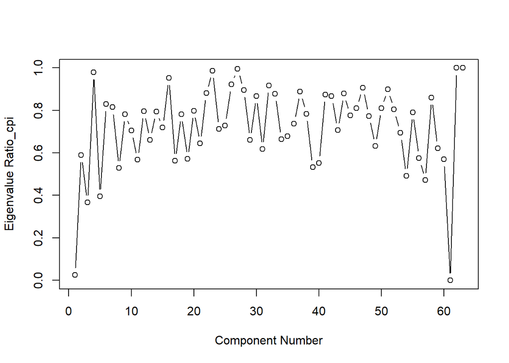

```r
#Perform PCA on X and fake.testing.X
pca_cpi <- prcomp(X_cpi[,-1])
pca_test_cpi <- prcomp(fake.testing.X_cpi[,-1])
pca_ppi <- prcomp(X_ppi[,-1])
pca_test_ppi <- prcomp(fake.testing.X_ppi[,-1])

# Extract the principal components_cpi
##method1：Elbow method
eig_ratio_cpi <- pca_cpi$sdev[-1]^2 / pca_cpi$sdev[-length(pca_cpi$sdev)]^2
plot(eig_ratio_cpi, type = "b", ylab = "Eigenvalue Ratio_cpi", xlab = "Component Number")
```

```r
##method2：Kaiser criterion，get :n_factors equals to 19
n_factors_cpi <- sum(pca_cpi$sdev^2 > 1)

factors_cpi <- pca_cpi$x[, 1:n_factors_cpi]
factors_test_cpi <- pca_test_cpi$x[, 1:n_factors_cpi]
##The downlink code can make the winner factor the same, but this produces a large bias
##factors_test_cpi <- predict(pca_cpi, newdata = fake.testing.X_cpi[,-1])[,1:n_factors_cpi]
```

Accordingly, we obtain that the principal component factor of PPI is 28.

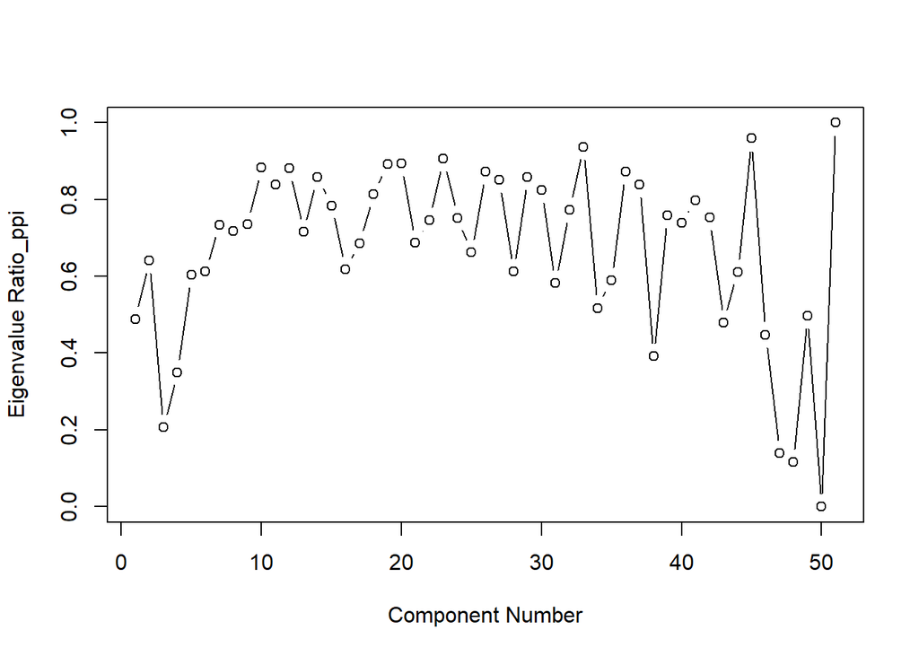

```r
#Extract the principal components_ppi, n_factors_ppi equals to 28，
eig_ratio_ppi <- pca_ppi$sdev[-1]^2 / pca_ppi$sdev[-length(pca_ppi$sdev)]^2
plot(eig_ratio_ppi, type = "b", ylab = "Eigenvalue Ratio_ppi", xlab = "Component Number")
```

```r
n_factors_ppi <- sum(pca_ppi$sdev^2 > 1)
factors_ppi <- pca_ppi$x[, 1:n_factors_ppi]
factors_test_ppi <- pca_test_ppi$x[, 1:n_factors_ppi]
```

After selecting the principal components, we utilized the auto.arima function for modeling. We trained the model using data from period 1 to 168 of X and obtained the corresponding model values for CPI and PPI for the same periods. We then calculated the Mean Squared Error (MSE) and the Root Mean Squared Error (RMSE) of these model values. Graphical visualizations were also created to better represent these results.

```r
# Estimate an auto-regressive model with external regressors (the factors)-cpi
model_cpi <- auto.arima(cpi, xreg = factors_cpi)
forecastcpi <- forecast(model_cpi, xreg = factors_cpi)
#calculate MSE and RMSE
forecastcpi_mse <- mean((forecastcpi$mean - cpi)^2)
forecastcpi_rmse <- sqrt(forecastcpi_mse)
print(paste0("主成分分析下的ARIAMA模型得到有关CPI的MSE: ", forecastcpi_mse))
```

```
## [1] "主成分分析下的ARIAMA模型得到有关CPI的MSE: 0.0585115857973596"
```

```r
print(paste0("主成分分析下的ARIAMA模型得到有关CPI的RMSE: ", forecastcpi_rmse))
```

```
## [1] "主成分分析下的ARIAMA模型得到有关CPI的RMSE: 0.24189168195157"
```

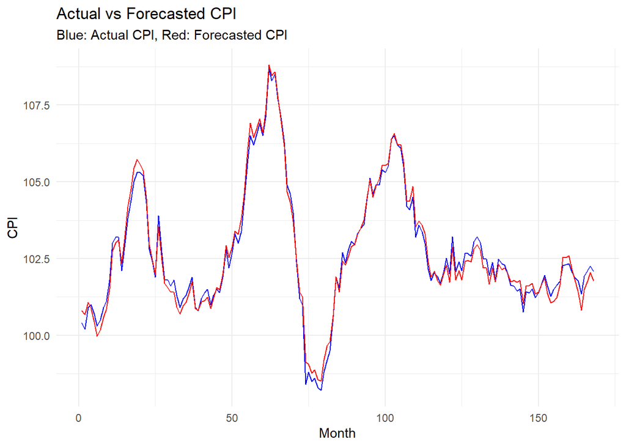

```r
#MSE is 0.0585115857973596, RMSE为0.24189168195157
#Draw pictures
plot_cpidata <- data.frame(
  Month = 1:168,
  Actual_CPI = cpi,
  Forecasted_CPI = forecastcpi$mean
)
ggplot(plot_cpidata, aes(x = Month)) +
  geom_line(aes(y = Actual_CPI), colour = "blue") +
  geom_line(aes(y = Forecasted_CPI), colour = "red") +
  labs(x = "Month", y = "CPI",
       title = "Actual vs Forecasted CPI",
       subtitle = "Blue: Actual CPI, Red: Forecasted CPI") +
  theme_minimal()
```

```r
# Estimate an auto-regressive model with external regressors (the factors)-ppi
model_ppi <- auto.arima(ppi, xreg = factors_ppi)
forecastppi <- forecast(model_ppi, xreg = factors_ppi)
#calculate MSE and RMSE
forecastppi_mse <- mean((forecastppi$mean - ppi)^2)
forecastppi_rmse <- sqrt(forecastppi_mse)
print(paste0("主成分分析下的ARIAMA模型得到有关PPI的MSE: ", forecastppi_mse))
```

```
## [1] "主成分分析下的ARIAMA模型得到有关PPI的MSE: 0.112467107193535"
```

```r
print(paste0("主成分分析下的ARIAMA模型得到有关PPI的RMSE: ", forecastppi_rmse))
```

```
## [1] "主成分分析下的ARIAMA模型得到有关PPI的RMSE: 0.335361159339502"
```

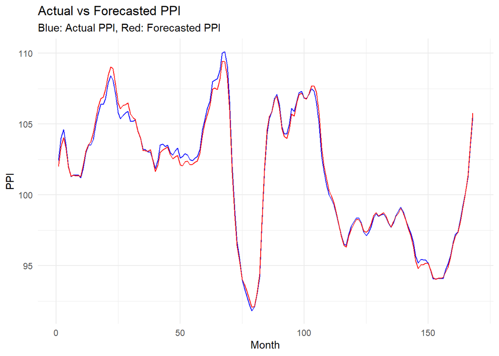

```r
#MSE为0.112467107193535, RMSE为0.335361159339502
#Draw pictures
plot_ppidata <- data.frame(
  Month = 1:168,
  Actual_PPI = ppi,
  Forecasted_PPI = forecastppi$mean
)
ggplot(plot_ppidata, aes(x = Month)) +
  geom_line(aes(y = Actual_PPI), colour = "blue") +
  geom_line(aes(y = Forecasted_PPI), colour = "red") +
  labs(x = "Month", y = "PPI",
       title = "Actual vs Forecasted PPI",
       subtitle = "Blue: Actual PPI, Red: Forecasted PPI") +
  theme_minimal()
```

Based on the established model, we imported the testing data for periods 169 to 198. This allowed us to obtain the corresponding CPI and PPI data, which were subsequently graphically represented. We then generated the forecast values for the next 30 periods for both CPI and PPI, which are presented in ‘forecast_cpi’ and ‘forecast_ppi’, respectively.

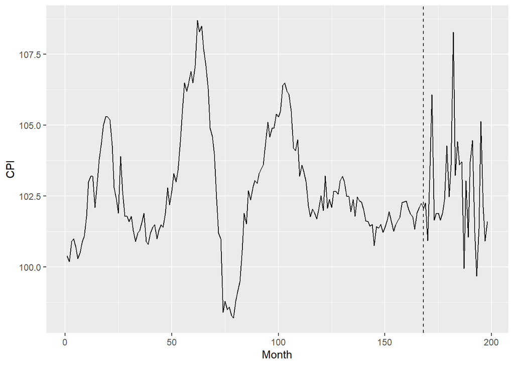

```r
#forecast cpi
forecast_testcpi <- forecast(model_cpi, xreg = factors_test_cpi)
# Create a data frame for plotting
plot_data_cpi <- data.frame(Month = c(1:198), CPI = c(cpi, forecast_testcpi$mean))
# Plot the data
ggplot(plot_data_cpi, aes(x = Month, y = CPI)) +
  geom_line() +
  geom_vline(xintercept = 168, linetype = "dashed")  # to show the point where out-of-sample forecasting starts
```

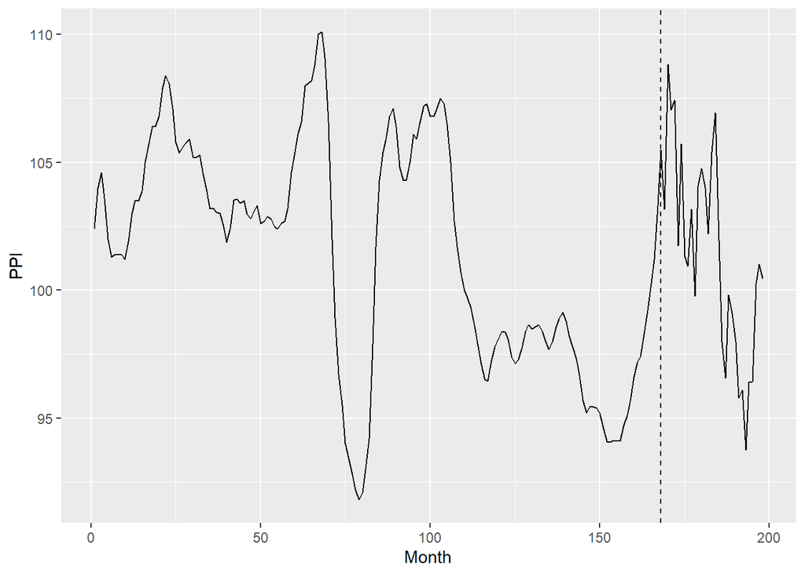

```r
#forecast ppi
forecast_testppi <- forecast(model_ppi, xreg = factors_test_ppi)
# Create a data frame for plotting
plot_data_ppi <- data.frame(Month = c(1:198), PPI = c(ppi, forecast_testppi$mean))
# Plot the data
ggplot(plot_data_ppi, aes(x = Month, y = PPI)) +
  geom_line() +
  geom_vline(xintercept = 168, linetype = "dashed")  # to show the point where out-of-sample forecasting starts
```

```r
# Converts the predicted values to data frames
forecast_cpi <- data.frame(Month = 169:198, Forecasted_CPI = forecast_testcpi$mean)
forecast_ppi <- data.frame(Month = 169:198, Forecasted_PPI = forecast_testppi$mean)
save(forecast_cpi, file = "forecast_cpi.RData")
save(forecast_ppi, file = "forecast_ppi.RData")
```

## 6. Random Forest

### 6.1 Random Forest——PPI

1. **Performing preparations**

First, select the variable column specified earlier for predicting PPI.

Second, in order to validate the effectiveness and accuracy of the method, it is decided to conduct experiments using known PPI data.

```r
rm(list = ls())
# Load the dataset
load(url("https://github.com/zhentaoshi/Econ5821/raw/main/data_example/dataset_inf.Rdata"))
library(randomForest)
```

```r
library(ggplot2)

# Selecting the specified PPI variable column
selected_cols <- c(3:13, 18, 26, 34:35, 37, 44, 47, 49, 51, 64, 71:79, 82:93, 102:108, 129, 142, 148:149)
X <- X[, selected_cols]
fake.testing.X <- fake.testing.X[, selected_cols]

# Splitting the data into training and test sets
# Using the first 120 observations as training data (train) and the remaining 48 observations as test data (test)
set.seed(123)
train_indices <- sample(1:168, 120, replace = FALSE)
train_ppi <- ppi[train_indices, 2]

train_X <- X[train_indices, -1]
test_ppi <- ppi[-train_indices, 2]
test_X <- X[-train_indices, -1]
train_ppi <- data.frame(train_ppi)
train_ppi <- as.numeric(train_ppi[[1]])
```

2. **Training the Random Forest model**

In order to train the random forest regression model, we need to find the optimal values for ntree and mtry parameters. Therefore, we set the ranges for the parameters ntree and mtry with a step size of 50 and 5, respectively. We iterate through all combinations and calculate the average error. We find the combination of ntree and mtry values that minimizes the average error.

- “ntree” represents the number of trees in the forest. A higher number of trees generally leads to better model performance but also requires more computational time.
- “mtry” represents the number of randomly selected features to consider at each node for splitting. A smaller mtry value can lead to overfitting, while a larger value can lead to underfitting.

Note: To avoid long waiting times during the final report presentation, the range of ntree and mtry parameters has been adjusted to be more precise. However, in actual practice, a larger range is often used to ensure finding the optimal ntree and mtry parameters.

```r
# Set the range of values for ntree and mtry.
ntree_values <- seq(400, 600, by = 50)
mtry_values <- seq(20, 40, by = 5)

# Initialize a result matrix.
results <- matrix(NA, nrow = length(ntree_values), ncol = length(mtry_values))

# Iterate through different combinations of ntree and mtry values.
for (i in 1:length(ntree_values)) {
  for (j in 1:length(mtry_values)) {
    # Train the random forest model.
    set.seed(123)
    rf <- randomForest(train_X, train_ppi, ntree = ntree_values[i], mtry = mtry_values[j])
    # Perform cross-validation and calculate the mean error
    set.seed(123)
    cv_error <- rep(NA, 10)
    for (k in 1:10) {
      cv_indices <- sample(1:120, 12, replace = FALSE)
      cv_train_X <- train_X[-cv_indices, ]
      cv_train_ppi <- train_ppi[-cv_indices]
      cv_test_X <- train_X[cv_indices, ]
      cv_test_ppi <- train_ppi[cv_indices]
      cv_rf <- randomForest(cv_train_X, cv_train_ppi, ntree = ntree_values[i], mtry = mtry_values[j])
      cv_error[k] <- mean((predict(cv_rf, cv_test_X) - cv_test_ppi)^2)
    }
    results[i, j] <- mean(cv_error)
  }
# This step may take a while as it computes the mean error for all combinations and selects the combination with the smallest mean error.
}

# Find the ntree and mtry values with the lowest mean error.
min_error <- min(results)
min_indices <- which(results == min_error, arr.ind = TRUE)
optimal_ntree <- ntree_values[min_indices[1]]
optimal_mtry <- mtry_values[min_indices[2]]
```

Based on the above testing, we have found that the optimal values for ntree and mtry are 500 and 30, respectively.

```r
# Train a random forest regression model using the randomForest() function with 500 trees and 30 random variables considered for splitting at each node.
rf_model <- randomForest(train_X, y = train_ppi, ntree = 500, mtry = 30)

# Use the predict() function to make predictions on the test data.
rf_pred <- predict(rf_model, newdata=test_X)
print(cbind(test_ppi, rf_pred))
```

```
##       PPI   rf_pred
## 1  102.40 102.38792
## 2  104.00 103.41372
## 3  104.60 104.44903
## 4  101.40 101.45858
## 5  101.20 101.53963
## 6  103.90 103.98628
## 7  106.40 106.47168
## 8  106.80 106.79798
## 9  105.78 105.71428
## 10 105.90 105.71360
## 11 104.50 104.22620
## 12 103.50 103.42946
## 13 103.10 102.99035
## 14 103.30 103.22065
```

[output cut: 34 more lines]

Therefore, we can use the trained model to make predictions for the next 30 unknown PPI values.

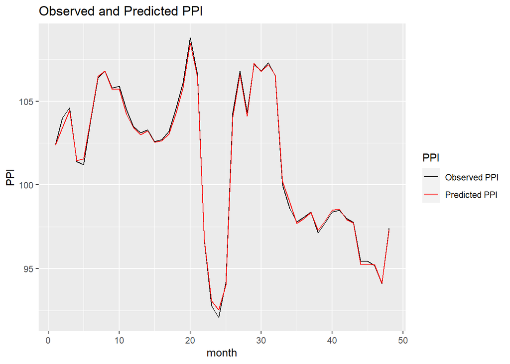

```r
# Combine test_ppi and rf_pred into a data frame.
df <- data.frame(month = 1:48,
                 observed = test_ppi,
                 predicted = rf_pred)
# Use ggplot to create a line plot.
# Plot the actual test data (48 observations in test) in black and the predicted data from random forest in red.
ggplot(df, aes(x = month)) +
  geom_line(aes(y = PPI, color = "observed_ppi")) +
  geom_line(aes(y = predicted, color = "predicted_ppi")) +
  labs(title = "Observed and Predicted PPI", y = "PPI") +
  scale_color_manual(values = c("black", "red"),
                     name = "PPI",
                     labels = c("Observed PPI", "Predicted PPI"))
```

3. **Evaluate the training performance of the random forest model**

MSE = 0.0373501949785841. Meaning that the random forest model’s predicted values have a smaller difference from the actual values.

```r
# Convert the variable test_ppi of type data.frame to numeric type.
test_ppi <- as.numeric(test_ppi$PPI)
# Calculate the Mean Squared Error (MSE) of the model.
rf_mse <- mean((rf_pred - test_ppi)^2)
# Print the MSE. A smaller MSE indicates better prediction performance of the model.
print(paste0("Random forest MSE: ", rf_mse))
```

```
## [1] "Random forest MSE: 0.0373501949785841"
```

RMSE = 0.193261985342654. Meaning that the random forest model’s predicted values have a smaller difference from the actual values.

```r
# Calculate the Root Mean Squared Error (RMSE) of the model.
rf_rmse <- sqrt(rf_mse)
# Print the RMSE. A smaller RMSE indicates better prediction performance of the model.
print(paste0("Random forest RMSE: ", rf_rmse))
```

```
## [1] "Random forest RMSE: 0.193261985342654"
```

4. **Generate the final predictions with fake.testing.X**

To generate the final predictions using the trained random forest model with fake.testing.X, follow the steps below:

First, split the data into a training set and a test set. In this case, use all observations as the training data.

Next, train a random forest regression model with ntree = 500 and mtry = 30.

Then, obtain the complete PPI predictions, including 30 predicted data points.

```r
#——————Generate the final predictions using the trained random forest model with fake.testing.X:

# Split the data into training set and test set.
# Use all observations as training data.
set.seed(123)
train_ppi2 <- ppi[, 2]
train_X2 <- X[, -1]
train_ppi2 <- data.frame(train_ppi2)
train_ppi2 <- as.numeric(train_ppi2[[1]])

# Train a random forest regression model using the randomForest() function with 500 trees and 30 random variables considered for splitting at each node.
rf_model2 <- randomForest(train_X2, y = train_ppi2, ntree = 500, mtry = 30)
# Use the trained model to predict fake.testing.X.
fake_testing_pred <- predict(rf_model2, newdata = fake.testing.X)
# Merge the predicted values with the original data.
predicted_ppi <- c(train_ppi2, fake_testing_pred)
print (predicted_ppi)
```

```
##
## 102.40000 104.00000 104.60000 103.60000 102.00000 101.30000 101.40000 101.40000
##
## 101.40000 101.20000 101.90000 103.00000 103.50000 103.50000 103.90000 105.00000
##
## 105.70000 106.40000 106.40000 106.80000 107.90000 108.40000 108.10000 107.10000
##
## 105.80000 105.38000 105.60000 105.78000 105.90000 105.20000 105.19000 105.30000
##
## 104.50000 104.00000 103.20000 103.20000 103.05000 103.01000 102.49000 101.87000
##
## 102.43000 103.52000 103.58000 103.40000 103.50000 102.98000 102.80000 103.10000
##
## 103.30000 102.60000 102.70000 102.90000 102.80000 102.50000 102.40000 102.60000
##
## 102.70000 103.20000 104.60000 105.40000 106.10000 106.60000 108.00000 108.10000
##
## 108.20000 108.80000 110.00000 110.10000 109.10000 106.60000 102.00000  98.90000
##
##  96.70000  95.50000  94.00000  93.40000  92.80000  92.20000  91.80000  92.10000
##
##  93.00000  94.20000  97.90000 101.70000 104.30000 105.40000 105.90000 106.80000
##
## 107.10000 106.40000 104.80000 104.30000 104.30000 105.00000 106.10000 105.90000
##
## 106.60000 107.20000 107.30000 106.80000 106.80000 107.10000 107.50000 107.30000
##
## 106.50000 105.00000 102.70000 101.70000 100.70000 100.00000  99.70000  99.30000
##
##  98.60000  97.92000  97.13000  96.52000  96.45000  97.24000  97.80000  98.06000
##
##  98.36000  98.37000  98.08000  97.38000  97.13000  97.30000  97.73000  98.38000
##
##  98.66000  98.49000  98.58000  98.64000  98.40000  97.98000  97.70000  98.00000
##
##  98.55000  98.89000  99.13000  98.80000  98.20000  97.76000  97.31000  96.68000
##
##  95.68000  95.20000  95.44000  95.43000  95.39000  95.19000  94.63000  94.08000
##
##  94.06000  94.12000  94.10000  94.10000  94.72000  95.10000  95.68000  96.62000
##
##  97.20000  97.40000  98.30000  99.20000 100.10000 101.20000 103.30000 105.50000
##         1         2         3         4         5         6         7         8
## 102.84445 101.75691 103.45219 103.78737 105.39675 105.21605 103.16275 102.57570
##         9        10        11        12        13        14        15        16
## 101.66512 102.39648 101.71174 101.91248  99.64052 103.07671 105.53510 100.05335
##        17        18        19        20        21        22        23        24
##  98.72400  97.03195  97.33327  97.07088  98.36661 101.05521 100.28373  99.44341
##        25        26        27        28        29        30
## 101.02211 101.77169 104.60917 104.33176 104.17434 101.89135
```

Finally, we generate the plot for PPI, where black represents the 168 known PPI observations, and red represents the 30 PPI predictions.

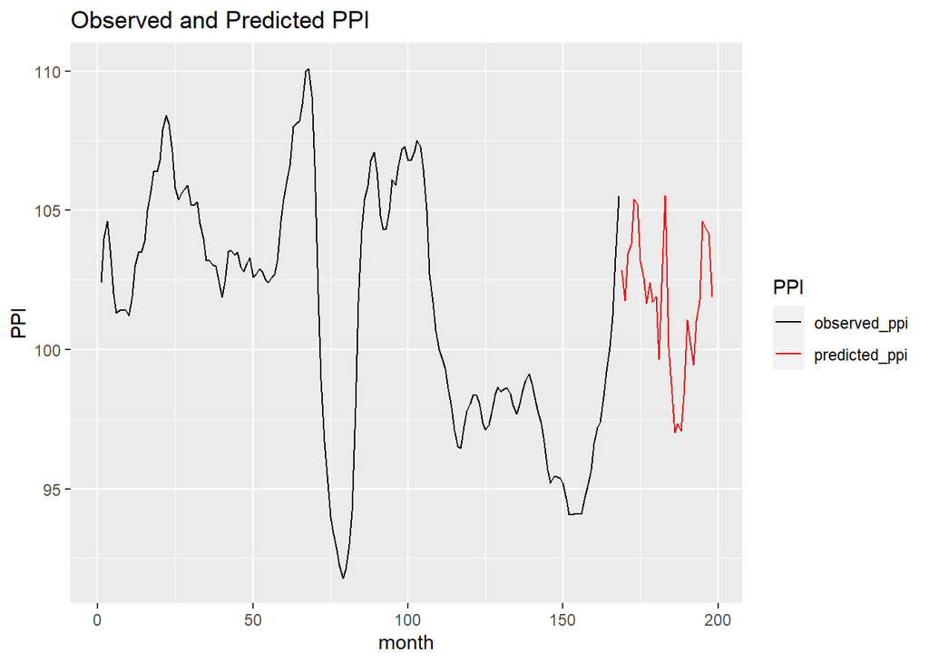

```r
# Original data set: observed_ppi
observed_ppi <- data.frame(month = 1:168, PPI = train_ppi2)
# Predicted data set: forecast_ppi
forecast_ppi <- data.frame(month = 169:198, PPI = fake_testing_pred)
# Merge the data sets: observed_and_forecast_ppi
observed_and_forecast_ppi <- rbind(observed_ppi, forecast_ppi)
# Add a color variable.
observed_and_forecast_ppi$color <- ifelse(observed_and_forecast_ppi$month <= 168, "observed_ppi", "predicted_ppi")
# Plot the graph.
ggplot(observed_and_forecast_ppi, aes(x = month, y = PPI, color = color)) +
  geom_line() +
  labs(title = "Observed and Predicted PPI", y = "PPI") +
  scale_color_manual(name = "PPI", values = c("observed_ppi" = "black", "predicted_ppi" = "red"))
```

### 6.2 Random Forest——CPI

1. **Performing preparations**

First, select the variable column specified earlier for predicting CPI.

Second, in order to validate the effectiveness and accuracy of the method, it is decided to conduct experiments using known CPI data.

```r
rm(list = ls())
# Load the dataset
load(url("https://github.com/zhentaoshi/Econ5821/raw/main/data_example/dataset_inf.Rdata"))
library(randomForest)
library(ggplot2)

# Selecting the specified CPI variable column
selected_cols <- c(14:18, 26, 28, 30, 34:35, 41, 48:51, 55, 57, 64, 66:70, 75:81, 94, 100:125, 127:129, 140:142, 147, 150)
X <- X[, selected_cols]
fake.testing.X <- fake.testing.X[, selected_cols]

# Splitting the data into training and test sets
# Using the first 120 observations as training data (train) and the remaining 48 observations as test data (test)
set.seed(123)
train_indices <- sample(1:168, 120, replace = FALSE)
train_cpi <- cpi[train_indices, 2]

train_X <- X[train_indices, -1]
test_cpi <- cpi[-train_indices, 2]
test_X <- X[-train_indices, -1]
train_cpi <- data.frame(train_cpi)
train_cpi <- as.numeric(train_cpi[[1]])
```

2. **Training the Random Forest model**

In order to train the random forest regression model, we need to find the optimal values for ntree and mtry parameters. Therefore, we set the ranges for the parameters ntree and mtry with a step size of 50 and 5, respectively. We iterate through all combinations and calculate the average error. We find the combination of ntree and mtry values that minimizes the average error.

- “ntree” represents the number of trees in the forest. A higher number of trees generally leads to better model performance but also requires more computational time.
- “mtry” represents the number of randomly selected features to consider at each node for splitting. A smaller mtry value can lead to overfitting, while a larger value can lead to underfitting.

Note: To avoid long waiting times during the final report presentation, the range of ntree and mtry parameters has been adjusted to be more precise. However, in actual practice, a larger range is often used to ensure finding the optimal ntree and mtry parameters.

```r
# Set the range of values for ntree and mtry.
ntree_values <- seq(200, 400, by = 50)
mtry_values <- seq(40, 60, by = 5)

# Initialize a result matrix.
results <- matrix(NA, nrow = length(ntree_values), ncol = length(mtry_values))

# Iterate through different combinations of ntree and mtry values.
for (i in 1:length(ntree_values)) {
  for (j in 1:length(mtry_values)) {
    # Train the random forest model.
    set.seed(123)
    rf <- randomForest(train_X, train_cpi, ntree = ntree_values[i], mtry = mtry_values[j])
    # Perform cross-validation and calculate the mean error.
    set.seed(123)
    cv_error <- rep(NA, 10)
    for (k in 1:10) {
      cv_indices <- sample(1:120, 12, replace = FALSE)
      cv_train_X <- train_X[-cv_indices, ]
      cv_train_cpi <- train_cpi[-cv_indices]
      cv_test_X <- train_X[cv_indices, ]
      cv_test_cpi <- train_cpi[cv_indices]
      cv_rf <- randomForest(cv_train_X, cv_train_cpi, ntree = ntree_values[i], mtry = mtry_values[j])
      cv_error[k] <- mean((predict(cv_rf, cv_test_X) - cv_test_cpi)^2)
    }
    results[i, j] <- mean(cv_error)
  }
# This step may take a while as it computes the mean error for all combinations and selects the combination with the smallest mean error.
}

# Find the ntree and mtry values with the lowest mean error.
min_error <- min(results)
min_indices <- which(results == min_error, arr.ind = TRUE)
optimal_ntree <- ntree_values[min_indices[1]]
optimal_mtry <- mtry_values[min_indices[2]]
```

Based on the above testing, we have found that the optimal values for ntree and mtry are 300 and 50, respectively.

```r
# Train a random forest regression model using the randomForest() function with 300 trees and 50 random variables considered for splitting at each node.
rf_model <- randomForest(train_X, y = train_cpi, ntree = 300, mtry = 50)

# Use the predict() function to make predictions on the test data.
rf_pred <- predict(rf_model, newdata=test_X)
print(cbind(test_cpi, rf_pred))
```

```
##       CPI   rf_pred
## 1  100.40 100.56677
## 2  100.20 100.61367
## 3  100.90 100.81469
## 4  101.10 100.95714
## 5  101.80 101.77509
## 6  103.00 103.04928
## 7  105.00 105.11661
## 8  105.30 105.25611
## 9  101.80 101.76761
## 10 101.80 101.76524
## 11 100.90 100.85363
## 12 101.50 101.50263
## 13 102.80 102.82880
## 14 102.20 102.24698
```

[output cut: 34 more lines]

Therefore, we can use the trained model to make predictions for the next 30 unknown CPI values.

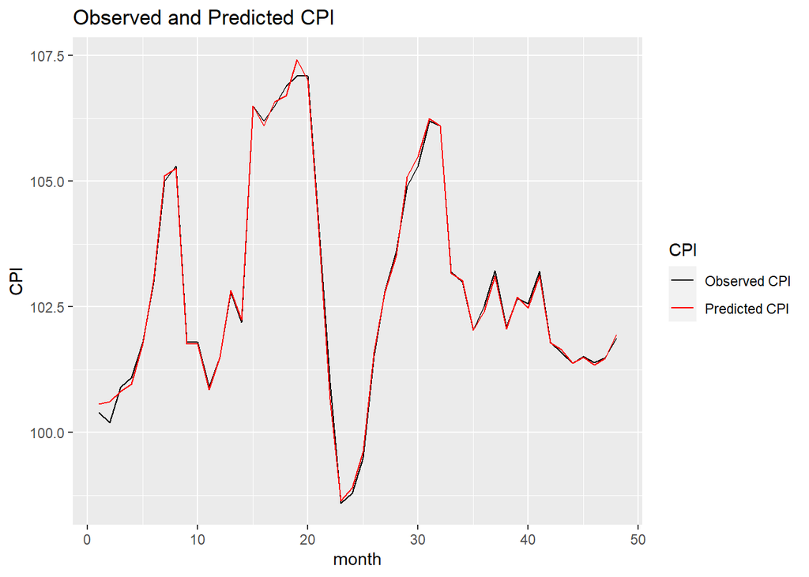

```r
# Combine test_cpi and rf_pred into a data frame.
df <- data.frame(month = 1:48,
                 observed = test_cpi,
                 predicted = rf_pred)
# Use ggplot to create a line plot.
# Plot the actual test data (48 observations in test) in black and the predicted data from random forest in red.
ggplot(df, aes(x = month)) +
  geom_line(aes(y = CPI, color = "observed_cpi")) +
  geom_line(aes(y = predicted, color = "predicted_cpi")) +
  labs(title = "Observed and Predicted CPI", y = "CPI") +
  scale_color_manual(values = c("black", "red"),
                     name = "CPI",
                     labels = c("Observed CPI", "Predicted CPI"))
```

3. **Evaluate the training performance of the random forest model**

MSE = 0.0148394993208728. Meaning that the random forest model’s predicted values have a smaller difference from the actual values.

```r
# Convert the variable test_cpi of type data.frame to numeric type.
test_cpi <- as.numeric(test_cpi$CPI)
# Calculate the Mean Squared Error (MSE) of the model.
rf_mse <- mean((rf_pred - test_cpi)^2)
# Print the MSE. A smaller MSE indicates better prediction performance of the model.
print(paste0("Random forest MSE: ", rf_mse))
```

```
## [1] "Random forest MSE: 0.0148394993208728"
```

RMSE = 0.121817483642016. Meaning that the random forest model’s predicted values have a smaller difference from the actual values.

```r
# Calculate the Root Mean Squared Error (RMSE) of the model.
rf_rmse <- sqrt(rf_mse)
# Print the RMSE. A smaller RMSE indicates better prediction performance of the model.
print(paste0("Random forest RMSE: ", rf_rmse))
```

```
## [1] "Random forest RMSE: 0.121817483642016"
```

4. **Generate the final predictions with fake.testing.X**

To generate the final predictions using the trained random forest model with fake.testing.X, follow the steps below:

First, split the data into a training set and a test set. In this case, use all observations as the training data.

Next, train a random forest regression model with ntree = 300 and mtry = 50.

Then, obtain the complete CPI predictions, including 30 predicted data points.

```r
# Split the data into training set and test set.
# Use all observations as training data.
set.seed(123)
train_cpi2 <- cpi[, 2]
train_X2 <- X[, -1]
train_cpi2 <- data.frame(train_cpi2)
train_cpi2 <- as.numeric(train_cpi2[[1]])

# Train a random forest regression model using the randomForest() function with 300 trees and 50 random variables considered for splitting at each node.
rf_model2 <- randomForest(train_X2, y = train_cpi2, ntree = 300, mtry = 50)
# Use the trained model to predict fake.testing.X.
fake_testing_pred <- predict(rf_model2, newdata = fake.testing.X)
# Merge the predicted values with the original data.
predicted_cpi <- c(train_cpi2, fake_testing_pred)
print (predicted_cpi)
```

```
##
## 100.4000 100.2000 100.9000 101.0000 100.7000 100.3000 100.5000 100.9000
##
## 101.1000 101.8000 103.0000 103.2000 103.2000 102.1000 103.0000 103.8000
##
## 104.4000 105.0000 105.3000 105.3000 105.2000 104.3000 102.8000 102.4000
##
## 101.9000 103.9000 102.7000 101.8000 101.8000 101.6000 101.8000 101.3000
##
## 100.9000 101.2000 101.3000 101.6000 101.9000 100.9000 100.8000 101.2000
##
## 101.4000 101.5000 101.0000 101.3000 101.5000 101.4000 101.9000 102.8000
##
## 102.2000 102.7000 103.3000 103.0000 103.4000 104.4000 105.6000 106.5000
##
## 106.2000 106.5000 106.9000 106.5000 107.1000 108.7000 108.3000 108.5000
##
## 107.7000 107.1000 106.3000 104.9000 104.6000 104.0000 102.4000 101.2000
##
## 101.0000  98.4000  98.8000  98.5000  98.6000  98.3000  98.2000  98.8000
##
##  99.2000  99.5000 100.6000 101.9000 101.5300 102.7000 102.3700 102.8100
##
## 103.0600 102.9500 103.3000 103.4800 103.6100 104.3700 105.1200 104.5900
##
## 104.9000 104.9000 105.4000 105.3000 105.5000 106.4000 106.5000 106.2000
##
## 106.1000 105.5000 104.2000 104.1000 104.5000 103.2000 103.5900 103.3700
##
## 103.0000 102.1500 101.7800 102.0500 101.9100 101.7000 102.0400 102.5200
##
## 102.0000 103.2200 102.0700 102.3900 102.1000 102.6700 102.6700 102.5700
##
## 103.0500 103.2100 103.0200 102.5000 102.4900 101.9500 102.3800 101.8000
##
## 102.4800 102.3400 102.2900 101.9900 101.6300 101.6000 101.4400 101.5100
##
## 100.7600 101.4300 101.3800 101.5100 101.2300 101.3900 101.6500 101.9600
##
## 101.6000 101.2700 101.4900 101.6400 101.7500 102.2800 102.3000 102.3300
##
## 102.0400 101.8800 101.7700 101.3400 101.9200 102.1000 102.2500 102.0800
##        1        2        3        4        5        6        7        8
## 104.4308 103.9596 103.2924 101.9433 102.5703 101.2469 101.2086 101.4861
##        9       10       11       12       13       14       15       16
## 102.6227 103.2898 106.3349 107.0213  99.9679 100.2375 102.7129 104.1676
##       17       18       19       20       21       22       23       24
## 104.0556 101.8744 102.4718 102.4341 102.3942 101.5850 101.4619 101.6264
##       25       26       27       28       29       30
## 102.2550 101.1031 101.7406 101.7053 101.7668 102.5502
```

Finally, we generate the plot for CPI, where black represents the 168 known CPI observations, and red represents the 30 CPI predictions.

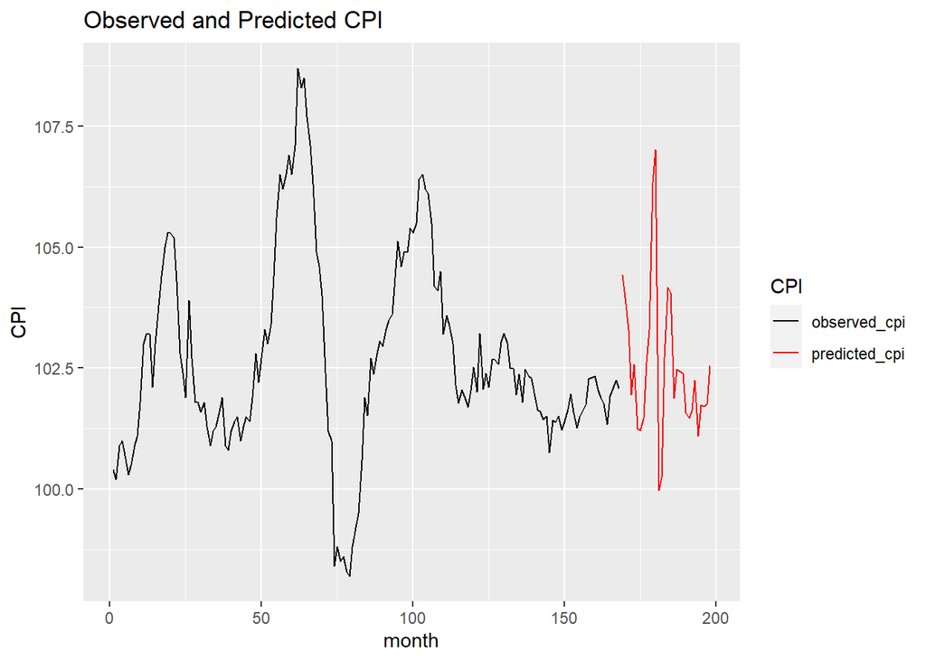

```r
# Original data set: observed_cpi
observed_cpi <- data.frame(month = 1:168, CPI = train_cpi2)
# Predicted data set: forecast_cpi
forecast_cpi <- data.frame(month = 169:198, CPI = fake_testing_pred)
# Merge the data sets: observed_and_forecast_cpi
observed_and_forecast_cpi <- rbind(observed_cpi, forecast_cpi)
# Add a color variable.
observed_and_forecast_cpi$color <- ifelse(observed_and_forecast_cpi$month <= 168, "observed_cpi", "predicted_cpi")
# Plot the graph.
ggplot(observed_and_forecast_cpi, aes(x = month, y = CPI, color = color)) +
  geom_line() +
  labs(title = "Observed and Predicted CPI", y = "CPI") +
  scale_color_manual(name = "CPI", values = c("observed_cpi" = "black", "predicted_cpi" = "red"))
```

## 7. Model Comparison and Inflation Rate Prediction

Considering the superior performance of the Random Forest model, we conclude that it is the more suitable choice for the subsequent prediction task. Thus, employing Random Forest to forecast CPI and subsequently calculate the inflation rate seems like a prudent approach. Random Forest is known for its capability to handle complex relationships, reduce over-fitting, and deliver robust predictions. Therefore, it holds promise for accurately forecasting the inflation rate based on CPI data.

In this part, we will use Random Forest to derive the prediction results of inflation rates based on CPI.

```r
# According to the given formula indicating the relationship with inflation rate and CPI, we extract two parts of CPI values whose lengths are both 30
predicted_cpi_values1 <- predicted_cpi[157:186]
predicted_cpi_values2 <- predicted_cpi[169:198]

# We derive the predicted inflation rate according to the formula using the two parts of CPI values.
# And we obtain the results of inflation rate prediction. ( from month 169 to month 198 ）【THE RESULTS OF OUR PROJECT】
inflation_rate_predictions <- log(predicted_cpi_values2) - log(predicted_cpi_values1)
print(inflation_rate_predictions)
```

```
##            1            2            3            4            5            6
##  0.026005699  0.016287827  0.009654064 -0.003786528  0.005183589 -0.006233238
##            7            8            9           10           11           12
## -0.005531440  0.001440233  0.006871419  0.011586346  0.039172329  0.047270905
##           13           14           15           16           17           18
## -0.043675395 -0.036459219 -0.005626392  0.021584405  0.014376991  0.006177872
##           19           20           21           22           23           24
##  0.012404093  0.009298444 -0.002229573 -0.016643184 -0.046909892 -0.051724479
##           25           26           27           28           29           30
##  0.022620434  0.008597997 -0.009510979 -0.023921515 -0.022241361  0.006612210
```

```r
# Then we generate the historical inflation rate. ( from month 13 to month 168 )
inflation_rate_13to168 <- log(predicted_cpi[13:168]) - log(predicted_cpi[1:156])
month_inflation_rate_13to168 <- 13:168
historical_inflation_rate <- data.frame(month_inflation_rate_13to168, inflation_rate_13to168)
print(historical_inflation_rate)
```

```
##     month_inflation_rate_13to168 inflation_rate_13to168
## 1                             13           0.0275066458
## 2                             14           0.0187845365
## 3                             15           0.0205990609
## 4                             16           0.0273454539
## 5                             17           0.0360838757
## 6                             18           0.0457946552
## 7                             19           0.0466556916
## 8                             20           0.0426834918
## 9                             21           0.0397531743
## 10                            22           0.0242612579
## 11                            23          -0.0019436352
## 12                            24          -0.0077821404
## 13                            25          -0.0126769128
## 14                            26           0.0174761729
```

[output cut: 142 more lines]

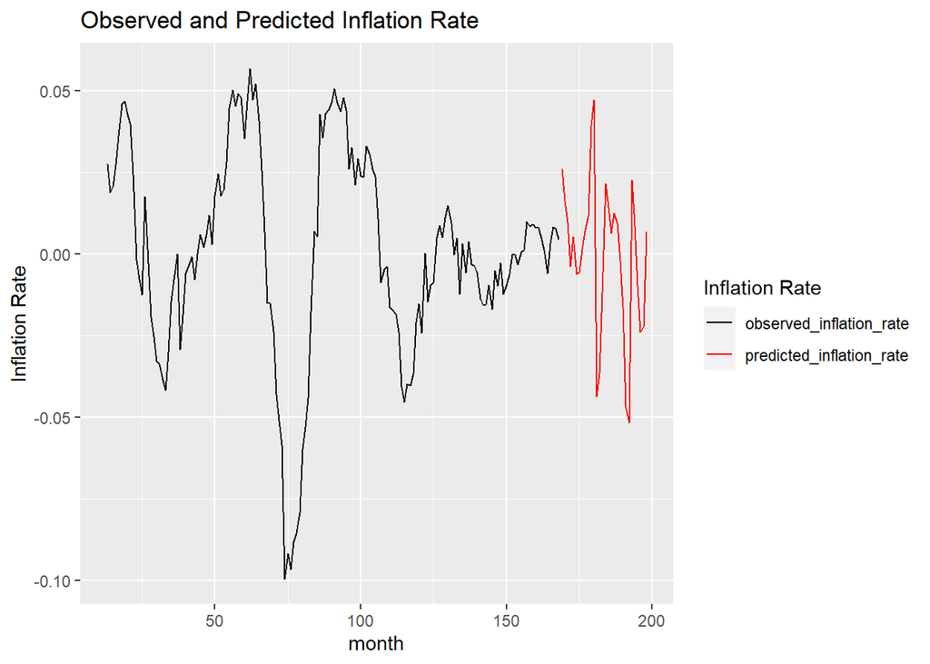

```r
# To generate plots, firstly we generate the observed inflation rates.
observed_inflation_rate <- data.frame(month = 13:168, Inflation_rate = inflation_rate_13to168)
# Secondly we generate the predicted inflation rates.
predicted_inflation_rate <- data.frame(month = 169:198, Inflation_rate = inflation_rate_predictions)
# Thirdly we combine these two data frames into one.
all_inflation_rate <- rbind(observed_inflation_rate, predicted_inflation_rate)
# Next we add a color variable.
all_inflation_rate$color <- ifelse(all_inflation_rate$month <= 168, "observed_inflation_rate", "predicted_inflation_rate")
# Lastly we generate the plot of inflation rate prediction based on CPI(random forest).
ggplot(all_inflation_rate, aes(x = month, y = Inflation_rate, color = color)) +
  geom_line() +
  labs(title = "Observed and Predicted Inflation Rate", y = "Inflation Rate") +
  scale_color_manual(name = "Inflation Rate", values = c("observed_inflation_rate" = "black", "predicted_inflation_rate" = "red"))
```